# Spectral analysis, estimation, and forecasting

## Detrending time series (estimation methods)

### Smoothing with a moving average filter

A pandas data frame allows computing a moving average with a specified window size. To test the effect of applying such a filter, run the below code. What are the filter coefficients used for the 7-point moving average filter? Note the number of NaN values at the start and end of each result when applying a 3-point and 7-point filter. By default, the length of the filter should be odd, but in case it is even, more of the filter is placed backward in time than forward.

Note: alternatively, we can use **convolve()** from **scipy.signal** to convolve a time series with specified filter coefficients as shown below.

```python
import numpy as np
import pandas as pd
import matplotlib.pyplot as plt

#3-point moving average filter

#pandas
x = np.arange(1,10+1)
y = pd.Series(x).rolling(window=3, center=True).mean() #NaNs will appear at ends

#alternatively: scipy
from scipy import signal
b = (np.ones(3))/3
y = signal.convolve(x, b, mode='valid') #NaNs are automatically removed

x = np.random.normal(loc=0, scale=1, size=100)
y3 = pd.Series(x).rolling(window=3, center=True).mean()
y7 = pd.Series(x).rolling(window=7, center=True).mean()
```

Plot the noise time series, and add line plots for both filter outputs `y3` and `y7`.

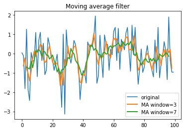

Read in and plot the time series for lake Huron. Then, apply a 3-point moving average filter and show the result superimposed. Also, apply instead a 5-point, 20-point, and 50-point moving average filter each separately. Add the results to the previous plot and include a suitable legend as shown below.

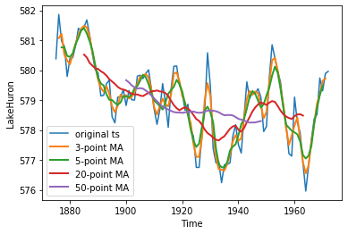

### Filtering in series

One can also apply moving average filters *in series*, i.e. apply a filter on the result of another filter and so forth. To try this out, apply a 2-point moving average filter on the lake Huron time series and show the result along with the original series. Then apply again the 2-point moving average filter on the filtered result, and show the line plot. Repeat this once more, i.e. filter the end result again with a 2-point MA filter and show the line plot.

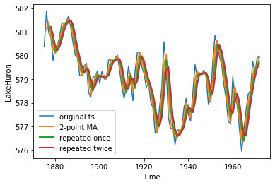

### Spencer filter

We may also create handcrafted filters by specifying the coefficients. Set up the 15-point Spencer filter discussed in the textbook. This filter allows polynomials of up to order 3 to pass undistorted; the filter is specified by:

$$f = \frac{1}{320}[-3,-6,-5,3,21,46,67,74,67,46,21,3,-5,-6,-3]$$

What is the sum of the filter coefficients? Apply the Spencer filter to the lake Huron time series and show the result. Hint: you may use scipy's **signal.convolve(..., mode='valid')** here, but be careful with the x-axis indexing when plotting.

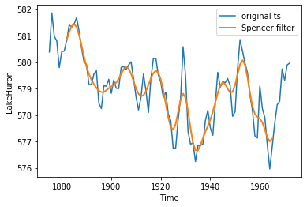

## Detrending & deseasonalizing by differencing

When both trend and seasonality are present, *differencing* can be used to remove both. The time series of monthly accidental deaths in the US contains a seasonal component of period 12. Read in and plot this time series. To remove seasonality, we may use the $\nabla_{12}$ operator which by definition gives $Y_t = \nabla_{12}X_t = X_t - X_{t-12}$. Apply this operator on the given time series using the pandas' **diff()** while specifying the required lag (i.e. `periods` argument). Show the plot as in Figure 1-26 of the textbook.

Note: another way to apply differencing is subtracting a forward shifted version of the time series (pandas' **shift(periods=...)**) from the original time series.

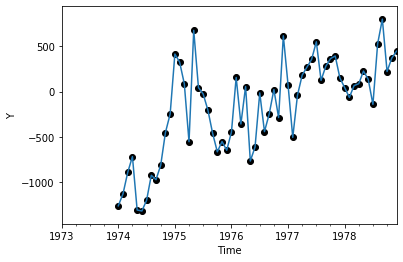

To remove trend in the resulting (deseasonalized) series, apply $\nabla Y_t = Y_t - Y_{t-1}$ whereby the equivalent final operation on $X_t$ is given by $\nabla \nabla_{12} X_t$. Plot the result as in Figure 1-27 of the textbook.

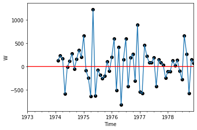

## Spectral analysis

We will explore spectral analysis through two examples: (i) a sinusoidal time series with noise and (ii) an AR(1) process.

### Sinusoidal time series with noise

Generate a random sample $Z$ of size 100 from a normal distribution with mean 0 and variance 1. Create the noisy sinusoidal time series $X(t) = 2cos(2 \pi /3 t) + Z(t)$, $t=0,2,...,99$, and plot it.

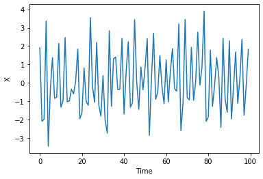

The periodogram can be computed using scipy's **periodogram()** (module: **scipy.signal**). Explore the code below.

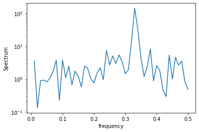

```python
from scipy import signal

f, pdensity = signal.periodogram(x)

plt.semilogy(f[1:], pdensity[1:]) #do not plot dc-value
plt.xlabel('frequency')
plt.ylabel('Spectrum')
plt.show()
```

Next, compute the cumulative periodogram (hint: use **cumsum()** and then normalize into $[0,1]$ through division by the total sum). If the time series were white noise, how would you expect the cumulative periodogram to look like?

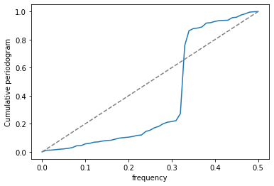

### AR(1) process

We already saw in the previous lab that to simulate an ARMA process, we can use the method **ArmaProcess()** from **statsmodels**. Alternatively, we could simulate the series ourselves using the ARMA equation. For instance, consider an AR(1) process with

$$X_t = \frac{1}{3} X_{t-1} + Z_t$$

Generate a random sample $Z$ of size 100 from a normal distribution with mean 0 and variance 1. Initialize the first element of the desried AR(1) time series, $X(0)$, as the first element of $Z$. Then for the remaining elements, use the AR(1) equation above to generate $X(1)$ through $X(99)$. Finally, plot the time series, its sample ACF, sample PACF, periodogram, and cumulative periodogram.

## Simulation

We revisit simulation of ARIMA processes before proceeding with estimation and forecasting. Simulate an ARMA(2,2)-process, an MA(1)-process with $\theta=0.8$, and an MA(1)-process with $\theta=0.01$ as shown below. Plot both simulated MA(1) series in the same figure with proper legend.

```python
from statsmodels.tsa.arima_process import ArmaProcess

model = ArmaProcess([1, -0.8897, 0.4858], [1, -0.2279, 0.2488]) #ARMA(2,2)
ts0 = model.generate_sample(nsample=100)

model = ArmaProcess([1], [1, 0.8]) #MA(1)
ts1 = model.generate_sample(nsample=100)

model = ArmaProcess([1], [1, 0.01]) #MA(1)
ts2 = model.generate_sample(nsample=100)
```

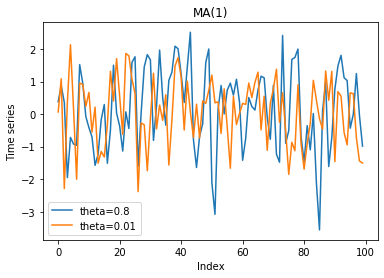

## Model (parameter) estimation

To estimate the parameters for a specified model order, the method **ARIMA()** from **statsmodels.tsa.arima.model** can be used for MA, AR, and ARMA processes alike. Let us try to estimate model parameters for the three simulated series above since we know their originating processes. Run the below commands and inspect the estimated values; how do these compare with the theoretical ones?

Note that the summary tables can be transformed into HTML and stored in a data frame from which certain important fields can then be accessed such as `coef` which includes the estimated coefficients, intercept, and $\sigma^2$ (`sigma2`). This is shown in the last 2 lines below.

```python
#import sys
#!{sys.executable} -m pip install lxml
#or %pip install lxml #Note: you may need to restart the kernel to use updated packages.
#import lxml

from statsmodels.tsa.arima.model import ARIMA

model = ARIMA(ts1, order=(0, 0, 1)).fit()
model.summary()

model = ARIMA(ts2, order=(0, 0, 1)).fit()
model.summary()

model = ARIMA(ts0, order=(2, 0, 2)).fit()
model.summary()

table_in_html = model.summary().tables[1].as_html()
df_summary = pd.read_html(table_in_html, header=0, index_col=0)[0]
```

Next, we will conduct an experiment in which we will repeatedly simulate an AR(1) time series of 100 samples with $\phi=0.8$, and estimate the parameter $\phi$ using **ARIMA** a 1000 times while storing the estimated value each time. Run the experiment and plot a histogram of the stored 1000 estimates of $\phi$. How does the distribution look like? Compute the mean of the estimates; is it close to the theoretical value?

## Forecasting

Once model parameters have been estimated, predictions can be done using `forecast()` as shown below, say for a horizon of 2 samples ahead.

```python
model = ArmaProcess([1], [1, 0.8])      #MA(1)
x = model.generate_sample(nsample=100)  #simulation

model = ARIMA(x, order=(0, 0, 1)).fit() #estimation
y_pred = model.forecast(steps=2)

#alternatively: same result
start = len(x)
end = len(x) + 1
y_pred = model.predict(start=start, end=end, typ='levels')
```

Simulate an AR(2) time series with coefficients (1.5, -0.75) with mean 30 as shown below. Reserve the first 40 samples as training set for estimating model parameters, whereas the last 10 samples will be used as test set to compare with forecasted values. Then fit an AR(2) model using the training set and plot the series along with forecasts for the next 10 instances. Note that the 95% confidence limits can be obtained from the summary tables of the fitted model (particularly: `sigma2` is useful). Also, the horizontal line in the plot is the estimated intercept (i.e. `const` from the model summary tables). Finally, add the actual (test) samples in the forecasted region. Display both the actual (test) values and the forecasted ones side by side (as columns) in a data frame for comparison.

```python
model = ArmaProcess([1, -1.5, 0.75], [1])
x = model.generate_sample(nsample=50) + 30
```

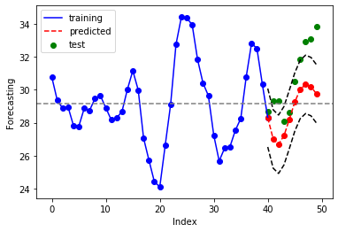

|  | true | predicted |
| --- | --- | --- |
| 0 | 28.674523 | 28.300096 |
| 1 | 29.320047 | 27.017123 |
| 2 | 29.317372 | 26.697072 |
| 3 | 28.078520 | 27.211884 |
| 4 | 28.632706 | 28.203741 |
| 5 | 30.487264 | 29.250864 |
| 6 | 31.864093 | 30.014018 |
| 7 | 32.921422 | 30.322657 |
| 8 | 33.074144 | 30.188146 |
| 9 | 33.837507 | 29.757198 |

## Residual diagnostics

Plot the time series for lake Huron which spans from 1875 till 1972. Fit a linear model to the series and show the model with the series in the same figure.

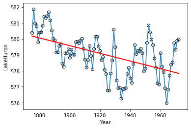

Let's now examine the residuals of the model. Plot the residual series, and also show the ACF and PACF of the residuals series. What can we conclude from these plots. What would you say are suitable $p$ and $q$ values if we were to fit an ARMA($p,q$) model?

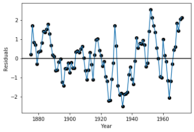

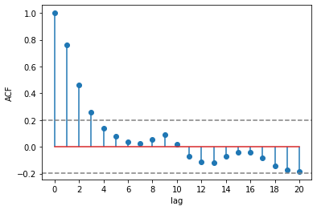

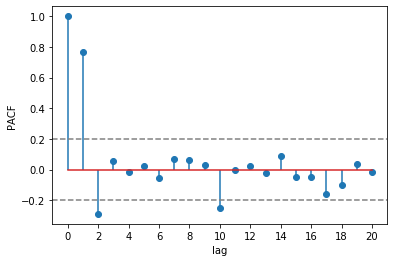

Estimate the parameters of the ARMA($p,q$) model you have selected based on the ACF and PACF plots. Finally, we are ready for diagnostic checking of residuals after fitting this ARMA($p,q$) model; if the residuals resemble white noise, then our model is accurate.

1. Begin by plotting the residual series: does it resemble white noise? Particularly, is there any trend or seasonality?
2. Plot the cumulative periodogram. Does it resemble that of white noise?
3. Plot the ACF of the residual series and compare to what you would expect of a white noise series.
4. Plot a histogram of the residuals. Often residuals would also follow a normal distribution (i.e. Gaussian white noise). Is this the case?
5. Create a normal QQ-plot (i.e. quantile-quantile plot) and add the first bisector ($y=x$) or QQ-line. Are the actual and theoretical (normal) quantiles close?
6. Use the Shapiro-Wilk test to assess normality. What is the p-value returned from this test? Can we say the residuals are normally distributed?

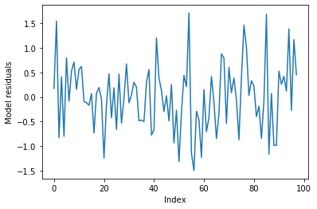

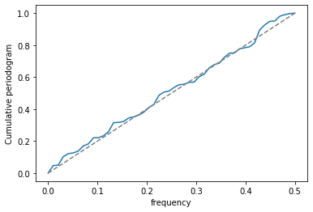

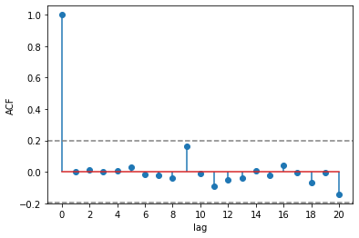

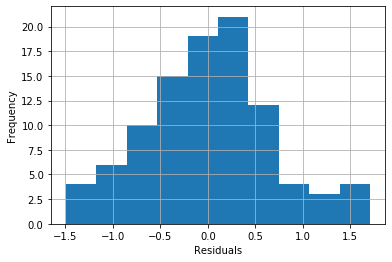

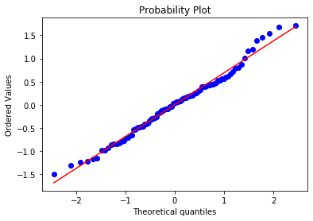

```
Shapiro-Wilk test: stat=0.9861517548561096, pvalue=0.3976055085659027
```